# Application for Clearwater Analytics

Author

Shubha Swarnim Singh

This is a dataset that i used while i took CSC Data Visualization. I have followed up with few models to predict the number of streams for each song in the test dataset based on the features: Danceability, Energy, Loudness, Speechiness, Acousticness, and Duration_min. I goggled a little bit about how we can create a perfect model for this kind of dataset. One way was to LASSO and use a Linear regression after was the answer. It was because LASSO reduces the complexity of the model if we have different variables and Linear regression uses ht best impacting variable to predict the model. After then i also used Linear gradient model and compared it with the previous one and used the best one on test set. This is an example of one of the reports that i have done which i would like to be considered in my application for the job as well.

# Introduction

For this project, I selected a Spotify dataset to explore and model as the final submission for CSC Data Visualization. Music resonated strongly with many students during our class introductions, making it an ideal and engaging subject for predictive modeling.

The data set provides details on several tracks by the artists, featuring columns like “Artist,” “Track,” “Album,” and numeric values reflecting characteristics of each song. Notably, the dataset includes attributes such as dance ability, energy, loudness, speechiness, acoustics, and duration. Each row corresponds to a specific track, with associated quantitative metrics offering insights into the musical features of different songs.

## Dataset Overview

The dataset includes various Spotify tracks, with features such as:

- **Artist**: The name of the musician or band that performed the track.
- **Track**: The title of the song.
- **Album**: The name of the album in which the track is included.
- **Album_type**: The category of the album, such as single, EP, or full-length album.
- **Danceability**: A numerical measure of how suitable the track is for dancing.
- **Energy**: A measure of the intensity and activity level of the track.
- **Loudness**: The overall volume level of the track in decibels.
- **Speechiness**: A measure of the amount of spoken words in the track.
- **Acousticness**: A measure indicating the likelihood of the track being acoustic.
- **Instrumentalness**: A measure of the absence of vocals in the track.
- **Liveness**: A measure indicating the probability of the track being recorded live.
- **Valence**: A measure of how positive or happy the track sounds.
- **Tempo**: The speed of the track, measured in beats per minute (BPM).
- **Duration_min**: The length of the track in minutes.
- **Title**: The official name or title of the track.
- **Channel**: The platform or YouTube channel where the track is published.
- **Views**: The total number of times the track has been viewed.
- **Likes**: The number of likes the track has received.
- **Comments**: The number of comments on the track.
- **Licensed**: Indicates whether the track is officially licensed.
- **Official_video**: Specifies whether the track has an official music video.
- **Stream**: The total number of times the track has been streamed on platforms like Spotify.
- **EnergyLiveness**: A combined metric that measures both the intensity and live presence of the track.
- **Most_playedon**: The platform where the track has been played the most.

Variables with excessive missing values or no predictive value were removed.

# Objective

The primary goal is to **predict the number of streams for a song** based on selected audio and metadata features. This will be done using two primary regression models:

- **LASSO Regression**
- **Multiple Linear Regression**

In addition, a manual implementation of **gradient descent optimization** is included to demonstrate the underlying mechanics of how linear regression parameters can be estimated through iterative techniques. While gradient descent is not a distinct model itself, it offers valuable educational insight.

Each model is evaluated based on prediction performance, and plots are analyzed to interpret results and assess modeling assumptions.

# Libraries

First, we load the required libraries that will help us process data, visualize patterns, and build models.

```r
# Using suppresspackagestartupmessages to suppress all the comments for easy readability.
suppressPackageStartupMessages({
  library(readr)
  library(dplyr)
  library(knitr)
  library(tidyverse)
  library(tidymodels)
  library(caret)
  library(ISLR2)
  library(readODS)
  library(ggrepel)
  library(glmnet)
})

tidymodels_prefer()
```

# Data processing

We read the dataset, drop missing values, and remove columns with zero variance to simplify modeling.

```r
#reading the data set
spotify <- read_csv("~/Downloads/spotify_dataset.csv")
spotify <- spotify |>
  drop_na()

# Identify columns with zero variance
zero_var_cols <- spotify |>
  summarise(across(everything(), sd, na.rm = TRUE)) |>
  select_if(~ . == 0) |>
  names()
# Remove columns with zero variance
spotify_data <- spotify |>
  select(-all_of(zero_var_cols))

head(spotify_data)
```

```
# A tibble: 6 × 16
  Track   Album Album_type Danceability Energy Loudness Speechiness Acousticness
  <chr>   <chr> <chr>             <dbl>  <dbl>    <dbl>       <dbl>        <dbl>
1 Feel G… Demo… album             0.818  0.705    -6.68      0.177     0.00836
2 Rhines… Plas… album             0.676  0.703    -5.82      0.0302    0.0869
3 New Go… New … single            0.695  0.923    -3.93      0.0522    0.0425
4 On Mel… Plas… album             0.689  0.739    -5.81      0.026     0.0000151
5 Clint … Gori… album             0.663  0.694    -8.63      0.171     0.0253
6 DARE    Demo… album             0.76   0.891    -5.85      0.0372    0.0229
# ℹ 8 more variables: Instrumentalness <dbl>, Duration_min <dbl>,
#   Channel <chr>, Views <dbl>, Likes <dbl>, Comments <dbl>, Stream <dbl>,
#   most_playedon <chr>
```

The wrangling process is done. Everything has been cleared and it is ready to be used for data analysis. the dataset now can be used in interpreting and visualizing graphs.

## Distribution of Danceability

This histogram shows that most tracks have danceability scores between 0.5 and 0.8, indicating moderately high suitability for dancing.

Now, we are visualizing the graph that will provide people with appropriate information and they can learn from it too. This graph represents the danceability of songs which means if the dance can be danced into or not. A histogram with the frequency of dance abilities will show how many songs on Spotify can be danced into. We do this to visualize a variable used from the dataset.

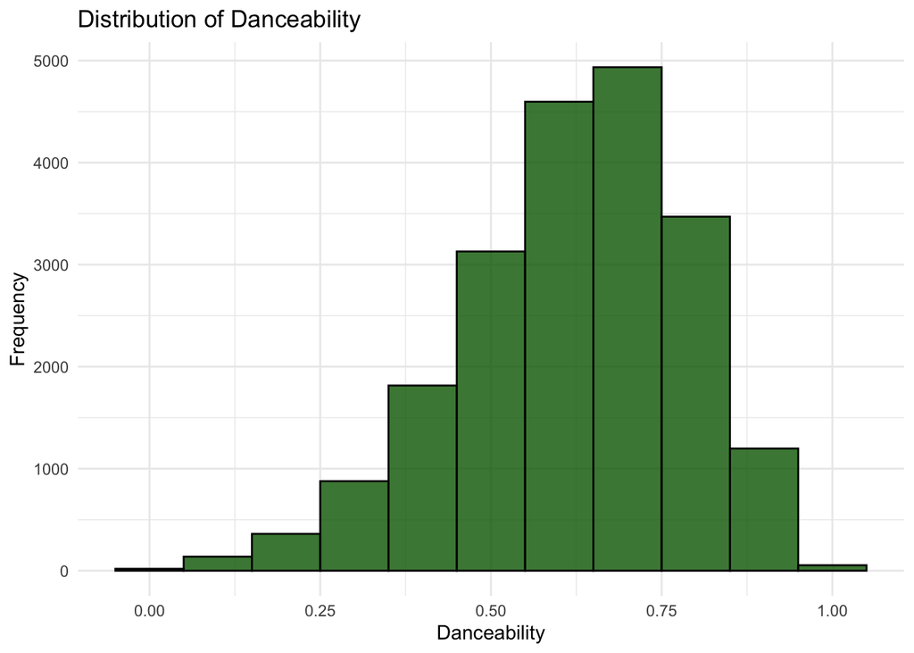

```r
ggplot(spotify_data, aes(x = Danceability)) +
  geom_histogram(binwidth = 0.1, fill = "darkgreen", color = "black", alpha = 0.8) +
  labs(title = "Distribution of Danceability",
       x = "Danceability", y = "Frequency") +
  theme_minimal()
```

## Data Splitting

Now, we will split our Spotify dataset into training and test sets. This is crucial for building and evaluating our models. The training set will be used to train the models, while the test set will be used to evaluate their performance. Setting a seed ensures that the split is reproducible.

```r
set.seed(427)

# Split the data into training and test sets
spotify_split <- initial_split(spotify_data, prop = 0.75, strata = Stream)
spotify_train <- training(spotify_split)
spotify_test <- testing(spotify_split)
```

# Our Model

Since i mentioned at the beginning that the one of the best ways to model this dataset was to LASSO at the beginning and use multiple linear regression. We will do so by following:

## Lasso Regression

```r
# Prepare the data for Lasso
x_train <- model.matrix(Stream ~ Danceability + Energy + Loudness + Speechiness + Acousticness + Duration_min, spotify_train)[,-1]
y_train <- spotify_train$Stream

# Fit Lasso model
lasso_model <- cv.glmnet(x_train, y_train, alpha = 1)

# Best lambda value
best_lambda <- lasso_model$lambda.min

# Coefficients of the model
selected_features <- coef(lasso_model, s = best_lambda)
selected_features
```

```
7 x 1 sparse Matrix of class "dgCMatrix"
                     s1
(Intercept)   337869981
Danceability   35287325
Energy       -184680984
Loudness        8956174
Speechiness   -86180256
Acousticness  -97632451
Duration_min   -1233514
```

## Multiple Linear Regression

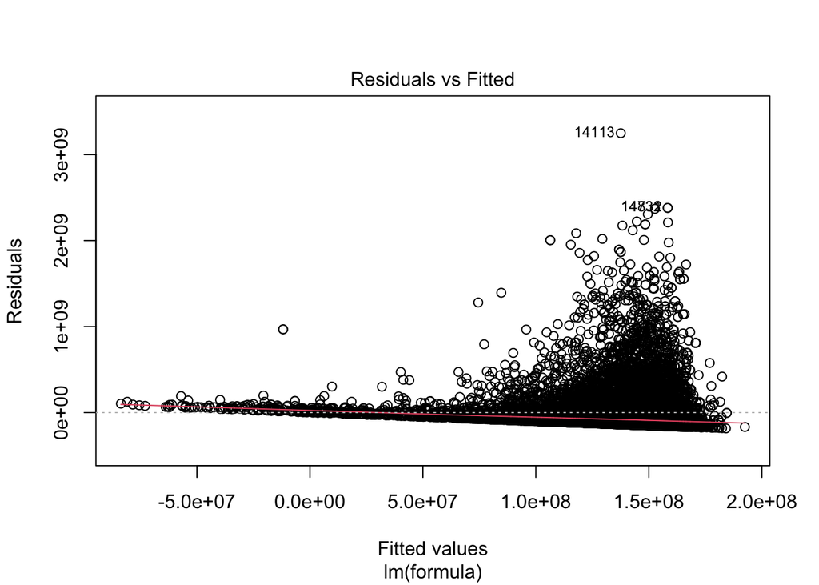

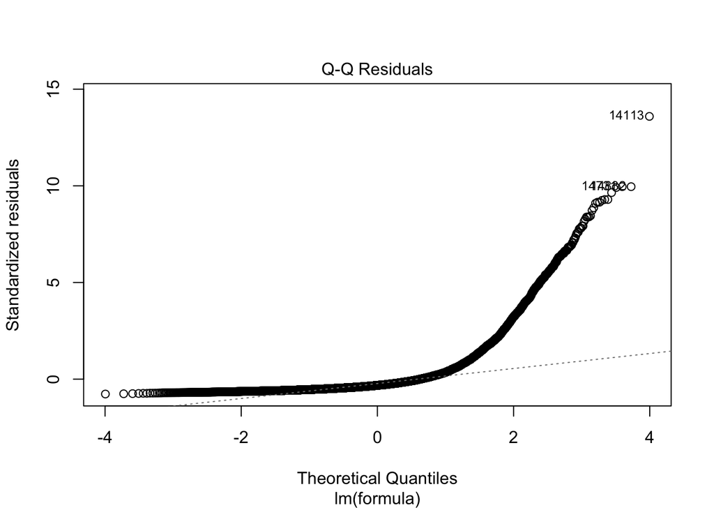

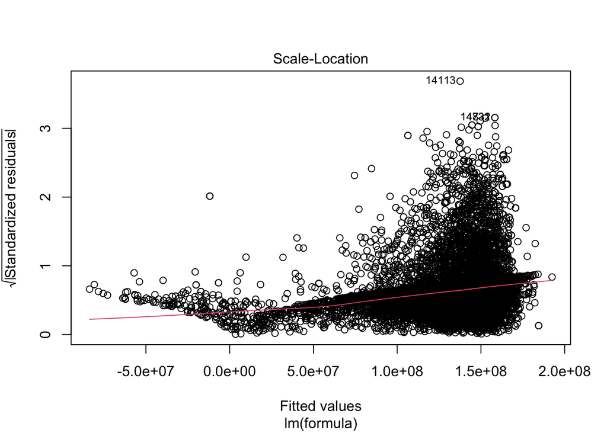

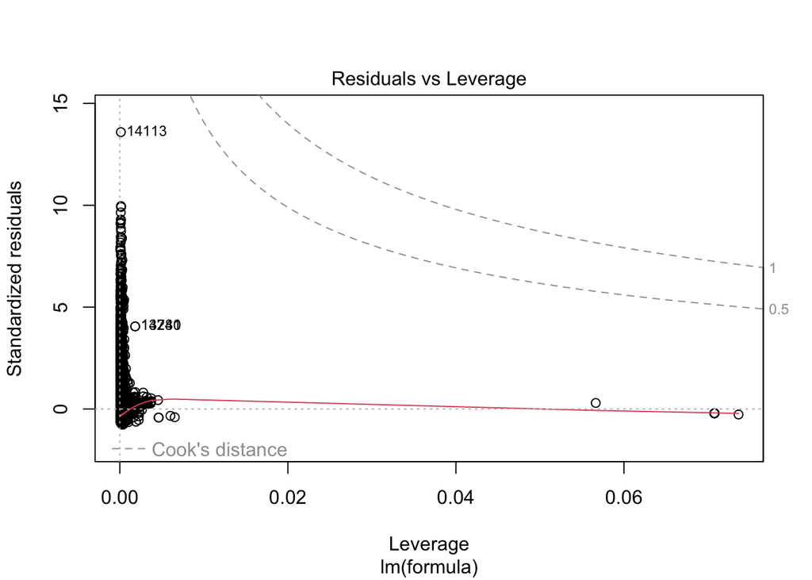

```r
# Extract selected features based on LASSO results
selected_features <- c("Danceability", "Loudness", "Duration_min")

# Build the formula for the linear model
formula <- as.formula(paste("Stream ~", paste(selected_features, collapse = " + ")))

# Fit the Multiple Linear Regression model
linear_model <- lm(formula, data = spotify_train)

# Plot diagnostics for the model
plot(linear_model)
```

```r
# Summary of the model
summary(linear_model)
```

```
Call:
lm(formula = formula, data = spotify_train)

Residuals:
       Min         1Q     Median         3Q        Max
-184087298 -116640921  -77181301    8444277 3248938464

Coefficients:
              Estimate Std. Error t value Pr(>|t|)
(Intercept)  150832429   10573121  14.266  < 2e-16 ***
Danceability  46218128   12500042   3.697 0.000219 ***
Loudness       5663014     447433  12.657  < 2e-16 ***
Duration_min  -1020516     877663  -1.163 0.244943
---
Signif. codes:  0 '***' 0.001 '**' 0.01 '*' 0.05 '.' 0.1 ' ' 1

Residual standard error: 239100000 on 15440 degrees of freedom
Multiple R-squared:  0.01531,   Adjusted R-squared:  0.01512
F-statistic: 80.04 on 3 and 15440 DF,  p-value: < 2.2e-16
```

```r
# Predict on test data
linear_predictions <- predict(linear_model, newdata = spotify_test)
```

## Model Evaluation

```r
# Evaluate the model
linear_rmse <- sqrt(mean((linear_predictions - spotify_test$Stream)^2))
linear_rmse
```

```
[1] 244663584
```

# Gradient Descent

Gradient descent is presented as a manual optimization technique for linear regression. While `lm()` optimizes parameters automatically, this section illustrates how weights can be learned iteratively.

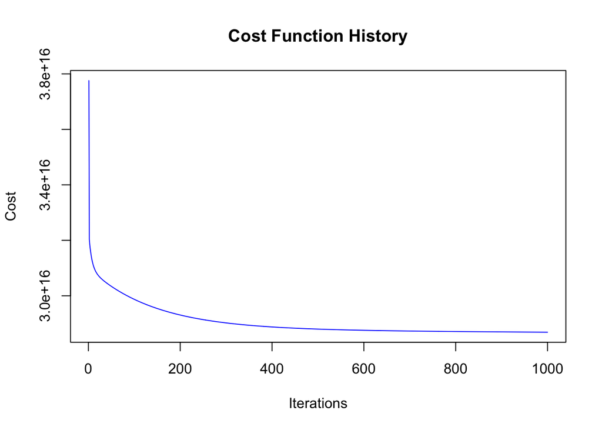

```r
# Gradient Descent Function
gradient_descent <- function(X, y, learning_rate = 0.01, iterations = 1000) {
  m <- nrow(X)
  n <- ncol(X)
  theta <- matrix(0, n, 1)
  cost_history <- numeric(iterations)

  for (i in 1:iterations) {
    predictions <- X %*% theta
    errors <- predictions - y
    gradient <- t(X) %*% errors / m
    theta <- theta - learning_rate * gradient
    cost_history[i] <- sum(errors^2) / (2 * m)
  }

  list(theta = theta, cost_history = cost_history)
}

# Prepare the data for gradient descent
selected_features <- c("Danceability", "Energy", "Loudness", "Speechiness", "Acousticness", "Duration_min")
X_train <- as.matrix(cbind(1, spotify_train[, selected_features]))
y_train <- as.matrix(spotify_train$Stream)

# Run gradient descent
result <- gradient_descent(X_train, y_train, learning_rate = 0.01, iterations = 1000)

# Extract the optimized parameters
theta <- result$theta
cost_history <- result$cost_history

# Plot the cost history
plot(cost_history, type = "l", col = "blue", xlab = "Iterations", ylab = "Cost", main = "Cost Function History")
```

## Model Evaluation

While useful for understanding optimization, this approach does not outperform the regression model fitted using `lm()`. We used variable stream as we are trying to find the number of streams for each song in the test dataset based on the features: Danceability, Energy, Loudness, Speechiness, Acousticness, and Duration_min.

```r
# Prepare the test data
X_test <- as.matrix(cbind(1, spotify_test[, selected_features]))
y_test <- as.matrix(spotify_test$Stream)

# Make predictions
predictions <- X_test %*% theta

# Evaluate the model
gradient_rmse <- sqrt(mean((predictions - y_test)^2))
gradient_rmse
```

```
[1] 245233722
```

# Prediction

```r
predicted_streams <- predict(linear_model, newdata = spotify_test)
# Comment out because it is too long
#predicted_streams
```

```r
results <- data.frame(Track = spotify_test$Track, Predicted_Streams = predicted_streams)

# Display the results
# print(results) Commented out because the results are too long
```

## Plotting the predicted information

Predictions from the linear regression model were collected and paired with the corresponding track names from the test set. A new dataframe combined predicted stream counts with song metadata, allowing for easier interpretation of the results. The top 10 tracks with the highest predicted stream counts were identified and plotted using a bar graph. This visualization highlighted the songs that the model believed would perform best based on their audio features.

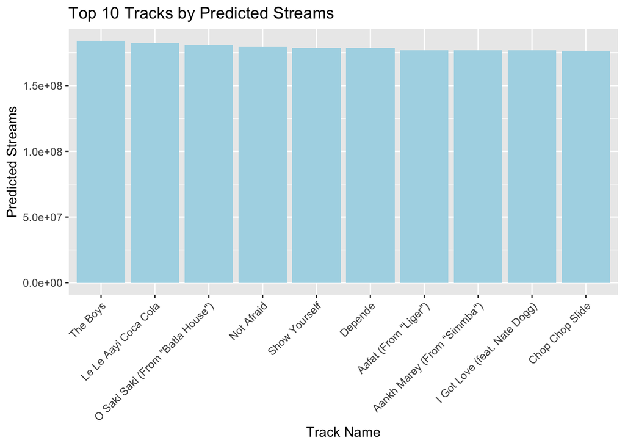

```r
results <- data.frame(Track = spotify_test$Track, Predicted_Streams = predicted_streams)

# Select the top 10 tracks based on predicted streams
top_10_results <- results |> arrange(desc(Predicted_Streams)) |> head(10)

# Plot the results
ggplot(top_10_results, aes(x = reorder(Track, -Predicted_Streams), y = Predicted_Streams)) +
  geom_bar(stat = "identity", fill = "lightblue") +
  labs(title = "Top 10 Tracks by Predicted Streams", x = "Track Name", y = "Predicted Streams") +
  theme(axis.text.x = element_text(angle = 45, hjust = 1))
```

Since we split the data, the full dataset contains only a limited number of songs in the test set, which could lead to inaccurate results. However, the model’s behavior remains the same.

# Resource

Citations: https://www.kaggle.com/datasets/sanjanchaudhari/spotify-dataset